# Untitled

Tadi Nguement Franck Armel

2026-04-28

# INTRODUCTION

Ce projet s’inscrit dans une démarche d’analyse statistique appliquée au domaine de l’assurance. À partir d’une base de données représentative des ménages français, nous cherchons à comprendre les mécanismes expliquant les montants de sinistres déclarés, leur fréquence, ainsi que la durée de souscription aux contrats. L’étude commence par une exploration descriptive de l’échantillon, mettant en évidence ses principales caractéristiques et les éventuelles problématiques rencontrées.

Nous proposons ensuite une tarification a priori, basée uniquement sur les caractéristiques des ménages, puis une tarification a posteriori, intégrant les informations sur les contrats souscrits. Des modèles économétriques adaptés sont mobilisés pour tenir compte de la structure des données : modèles Tobit et Double Hurdle pour les sinistres avec excès de zéros, régressions sur les comptes de sinistres, et modèles de durée (Kaplan-Meier et Cox) pour analyser la fidélité des assurés. Chaque étape du projet vise à produire des résultats interprétables, utiles à la prise de décision dans un contexte assurantiel.

# Analyse descriptive

Tout d’abord, dans notre jeu de donnée on peut relevé plusieurs variables qualitatives qui décrivent les caractèristiques sociodémographiques et économiques importantes des ménages français en contrat avec une socièté d’assurance.

La variable cs représente la catégorie socioprofessionnelle des individus. Le diagramme circulaire montre que la majorité des individus se situent dans la classe “Moyenne Inférieure”, suivie par la “Moyenne Supérieure”. Les classes “Modeste” et “Aisée” sont moins représentées dans l’échantillon. Cette distribution suggère une population principalement issue des couches intermédiaires.

Sur la catégorie socioprofessionnelle (pcs) des individus où on peut classifier les individus selon leur statut professionnel. les retraités constituent la catégorie la plus représentée, suivis de près par les ouvriers, ce qui montre une forte proportion de profils modestes ou inactifs. Viennent ensuite les professions intermédiaires et les employés, également bien présents. À l’inverse, les agriculteurs exploitants et les artisans, commerçants et chefs d’entreprise sont nettement moins représentés dans la population étudiée. Cette répartition reflète une structure sociale dominée par les classes populaires et les inactifs. ce qui peut refléter des différences d’âge ou de situation économique.

Ensuite l’analyse des variables quantitatives permet de mieux cerner les profils assurés ainsi que les comportements liés aux contrats.

Statistiques descriptives des variables quantitatives

| Variable | Min | Q1 | Median | Mean | Q3 | Max |
| --- | --- | --- | --- | --- | --- | --- |
| nbpers | 1.00 | 2.00 | 3.00 | 3.04 | 4.00 | 10.00 |
| NSin | 0.00 | 0.00 | 4.00 | 4.25 | 6.00 | 30.00 |
| Police1 | 0.00 | 0.54 | 1.95 | 3.75 | 5.02 | 54.98 |
| Sinistre1 | 0.00 | 0.00 | 0.00 | 1.24 | 0.00 | 355.00 |
| Duree | 0.00 | 23.00 | 42.50 | 249.11 | 233.00 | 9877.00 |
| reves | 1000.00 | 8500.00 | 11250.00 | 14879.95 | 16250.00 | 3416250.00 |
| RUC | 277.78 | 3823.53 | 5500.00 | 6277.52 | 7812.50 | 35294.12 |

La taille des ménages varie entre 1 et 10 personnes, avec une moyenne proche de 3. Le nombre total de sinistres (NSin) est très hétérogène, allant de 0 à 30, avec une médiane à 4, ce qui reflète une minorité de foyers très sinistrés.

Le montant des primes (Police1) varient très fortement (de 0 à plus de 50), la majorité des assurés payant entre 0,5 et 5. Le minimum à 0 peut signaler une absence temporaire de contrat ou une donnée manquante mal codée. Ce qui suggérant des profils d’assurance très différents. Il en va de même pour les revenus (reves) et les revenus unitarisés (RUC), où des valeurs extrêmes très élevées sont observées, justifiant une vigilance sur leur validité (valeurs aberrantes possibles). Si la majorité des foyers gagnent entre 8 000 et 16 000 euros, certains montants dépassent les 3 millions, ce qui est très vraisemblablement dû à des erreurs ou à des cas extrêmes très atypiques. Le revenu unitaire (RUC), qui tient compte de la taille du foyer, présente une moyenne d’environ 6 300 €, ce qui permet de mieux comparer le pouvoir d’achat entre foyers de tailles différentes.

La variable Duree, qui indique la durée de souscription, affiche un minimum cohérent (0 mois), mais le maximum atteint près de 10 000 mois, soit plus de 800 ans, ce qui est clairement aberrant. Cela indique une erreur de saisie ou un problème de format dans la base. La médiane de 42 mois est plus réaliste et indique une fidélité moyenne de 3 à 4 ans à l’assureur.

## Recherche des valeurs atypiques

Pour mieux comprendre la structure des variables continues et repérer d’éventuelles anomalies, nous avons utilisé des boxplots. Trois variables sont particulièrement sensibles aux valeurs extrêmes : la prime d’assurance (Police1), la durée du contrat (Duree), et le revenu annuel du foyer (reves).

Le boxplot montre de nombreuses valeurs extrêmes au-dessus de la borne supérieure, avec des montants atteignant plus de 50 unités, alors que la majorité des observations sont situées en-dessous de 10. Ces valeurs atypiques peuvent refléter des contrats spéciaux ou très complets, mais mériteraient d’être vérifiées. Une vérification des modalités associées à ces montants (type de foyer, revenu, etc.) permettrait d’en juger la pertinence.

La durée des contrats est en général inférieure à 500 mois, mais certains contrats dépassent 5 000 mois, soit plus de 400 ans ! Ces valeurs sont très probablement dues à une erreur de saisie (ex. : mauvaise unité, champ mal rempli). Une correction ou un filtrage de ces valeurs serait pertinent avant toute modélisation.

Le revenu annuel du foyer présente aussi des extrêmes très marqués. La majorité des revenus sont concentrés sous 50 000 €, mais certains foyers déclarent plus de 3 millions d’euros. Cela pourrait correspondre à de très hauts revenus, mais aussi à des erreurs de saisie ou à l’inclusion de revenus exceptionnels (vente de patrimoine, dividendes, etc.).

Ces trois variables contiennent des valeurs atypiques importantes. Certaines peuvent être réelles et révélatrices (revenus élevés, contrats complets), mais d’autres semblent invraisemblables (durées excessives). Pour la suite de l’analyse, un nettoyage ou une transformation (logarithme, winsorisation) pourrait être nécessaire afin de limiter l’impact de ces extrêmes.

## Analyse des sinistres

L’analyse des variables liées aux sinistres (Sinistre0, Sinistre1, Sinistre2, Sinistre3) permet d’évaluer la fréquence et la dispersion des déclarations de sinistres dans la population étudiée. On s’intéresse ici à la distribution de ces sinistres ainsi qu’à l’identification des profils sans sinistres ou avec un grand nombre.

Le graphique montre que la majorité des individus ont un sinistre nul ou très faible. Une concentration importante est observée autour de zéro, ce qui suggère que beaucoup de foyers n’ont pas eu de sinistres auto ou très peu coûteux.

Les données sur les sinistres révèlent une forte asymétrie : la majorité des individus n’ont que peu de sinistres, tandis qu’un petit nombre présentent des montants ou fréquences très élevés. Il sera essentiel de traiter ces extrêmes avec précaution, notamment dans une optique de modélisation du risque.

## Croisements stratégiques

Afin d’approfondir l’analyse, il est pertinent de croiser certaines variables quantitatives avec des variables sociales ou démographiques. Ces croisements permettent de mieux comprendre les profils de risque ou les niveaux de primes pratiquées selon les caractéristiques des assurés.

### Nombre de sinistres (NSin) selon la taille du foyer (nbpers)

On peut se demander si le nombre de personnes dans le foyer influence la fréquence des sinistres : un foyer plus grand peut impliquer davantage d’usagers de véhicules, donc potentiellement plus de sinistres.

### Montant de la prime d’assurance (Police1) selon la catégorie sociale (cs)

La catégorie sociale des assurés peut influencer le montant de leur prime d’assurance, notamment selon les garanties choisies, le type de véhicule ou le comportement de conduite.

Ces croisements montrent que certaines variables sociales (taille du foyer, catégorie sociale) influencent les montants de primes ou le nombre de sinistres. Ces relations ne sont pas toujours linéaires, mais elles offrent des pistes intéressantes pour la segmentation des profils de risque dans une optique assurantielle.

# Proposition de tarification à priori (Sans les polices) et à postériori (avec les polices)

La tarification consiste à fixer un prix dit prime d’assurance pour couvrir un risque. On note deux formes de tarification:

- La tarification à priori: Elle concerne les nouveaux clients, elle est basée sur des caractéristiques observables de l’assuré (âge, sexe, profession etc) ou du bien assuré. La prime est fixée avant la période de couverture.
- La tarification à postériori: Elle concerne les anciens assurés, déjà souscrits. Elle repose sur des données historiques telles que les sinistres observés et la prime est ajustée en fonction du comportement de l’assuré sur une période donnée, sur la durée de cotisation. Cependant elle rencontre le plus souvent un problème d’endogénéité des polices. Il convient alors de segmenter les clients selon le tarif à payer en fonction du risque couvert. Pour mieux approfondir sur le sujet, nous commencerons dans cette section de notre projet, d’abord à préparer les données ensuite nous étudierons la tarification à priori, ensuite nous étudierons la tarification à postériori en tenant compte de l’endogénéité possible des polices.

Commençons par retirer les observations avec Sinistre0 = 0.

## 2.1 Tarification a priori (sans les polices)

Afin d’élaborer une proposition de tarification a priori, nous avons estimé un modèle GLM gaussien sur la variable Sinistre0, en expliquant les montants de sinistres positifs par les caractéristiques sociodémographiques des ménages. Les résultats nous montrent que le niveau de revenu (mesuré par la variable crevpp) est un facteur déterminant du montant moyen de sinistre : plus le revenu est élevé, plus le montant des sinistres est important, avec un effet monotone croissant sur les quartiles de revenu. De même, la présence d’enfants influence fortement les sinistres autrement dit les ménages sans enfants présentent en moyenne un montant de sinistres supérieur d’environ 7,9 unités par rapport à ceux avec enfants. En revanche, les variables relatives à la région de résidence et à l’habitat n’apparaissent pas comme significatives dans l’explication du montant de sinistre.

Par la suite, un test de Breusch-Pagan a été réalisé pour détecter une éventuelle hétéroscédasticité des erreurs. Le test révèle une statistique BP = 54,785 pour 19 degrés de liberté, avec une p-value de 2,507×10⁻⁵. Cela nous pousse à rejeter l’hypothèse d’homoscédasticité au seuil de 5 %. Ainsi, l’hypothèse de variance constante des erreurs n’est pas vérifiée dans ce modèle. Par conséquent, l’estimation finale des coefficients est corrigée en utilisant des erreurs-types robustes (méthode de White via vcovHC) pour obtenir des tests de significativité fiables.

Donc, la tarification a priori proposée repose principalement sur le niveau de revenu et la présence d’enfants, deux facteurs significatifs et économiquement interprétables.

## 2.1 Tarification a posteriori (avec les polices)

Pour la tarification a posteriori, nous avons estimé un modèle à variables instrumentales (IV) sur Sinistre0 en traitant Police1 comme potentiellement endogène et en utilisant le quartile de revenu par personne (1er à 4e quartile), la présence d’enfants , la région de résidence, l’habitat et les catégories sociales de revenu comme instruments. Les coefficients montrent que, même après correction par IV, le niveau de revenu (crevpp) et l’absence d’enfants restent des déterminants majeurs du montant de sinistre (p < 0,001), et que seule Police1 a un impact significatif et positif (estimate = 0,0848, p = 0,015), suggérant un effet de sélection adverse ou de tarification de cette garantie. Les diagnostics confirment la robustesse de cette approche : le test de faiblesse des instruments (F ≃ 14,9, p < 2e-16) indique des instruments forts, tandis que le test de Hausman (statistique = 4,51, p = 0,034) rejette l’exogénéité de Police1, légitimant l’usage de l’IV. En revanche, le test de Sargan (χ² = 118,2, p < 2e-16) signale un rejet de la validité conjointe des instruments, ce qui invite à reconsidérer ou affiner la sélection instrumentale (par exemple en testant des sous-ensembles ou en recourant à un estimateur GMM robuste). Le modèle IV explique ainsi près de 73 % de la variabilité des montants de sinistre positif (R² ajusté ≃ 0,732) et fournit une prime de tarification a posteriori centrée sur crevpp, enfants et Police1 corrigée, tout en soulignant la nécessité de vérifier la robustesse des instruments pour garantir la fiabilité des coefficients.

Pour corriger l’endogénéité de la cotisation Police1, nous estimons en première lieu un modèle OLS où Police1 est expliquée par les instruments : quartiles de revenu (crevpp), présence d’enfants, région, type d’habitat (habi) et catégorie sociale de revenu (cs). Le modèle présente un R-squared ajusté de 3,1 %, indiquant que ces variables expliquent modérément la variabilité de Police1. Les coefficients montrent que les ménages des 3ᵉ et 4ᵉ quartiles de revenu cotisent significativement moins à la police 1 (p < 0,001 et p < 10⁻⁷), de même que les catégories sociales « Modeste » (p < 0,01) et « Moyenne inférieure » (p < 0,05). Quelques modalités d’habitat (notamment habi1, habi7 et habi8) exercent également un effet négatif significatif. En revanche, la présence d’enfants et la plupart des régions ne semblent pas influencer la cotisation. Le test global de significativité conjointe des instruments (F-statistic = 8,78, p < 2,2×10⁻¹⁶) confirme leur utilité, même si la statistique de première étape reste légèrement inférieure au seuil de 10 habituellement recommandé pour écarter totalement le risque d’instrument faible. Ces résultats valident néanmoins l’approche IV tout en soulignant la nécessité de rester prudent sur la force des instruments choisis.

Pour tester formellement l’endogénéité de la cotisation Police1, nous avons inclus dans un modèle auxiliaire les résidus de la première étape (resid_first) aux côtés de Police1. Le résultat est le suivant :

Coefficient de resid_first = –0,0767 (Std. Error = 0,0362), t = –2,12, p = 0,034. Comme la p-value associée est inférieure à 5 %, on rejette l’hypothèse nulle d’exogénéité de Police1. Autrement dit, les résidus issus de l’étape instrumentale capturent une partie de l’erreur structurelle du modèle, confirmant que Police1 est corrélée avec l’«erreur» et qu’une estimation OLS serait biaisée. Dès lors, l’usage d’un estimateur en deux étapes (IV/2SLS) est pleinement justifié pour obtenir des coefficients non biaisés.

Donc, on retient que notre double démarche – un modèle de gravité a priori axé sur le revenu et la présence d’enfants, suivi d’une correction IV de l’effet de Police1 – permet de construire une tarification à la fois juste et robuste face aux biais d’endogénéité.

Nous pouvons ainsi formuler des recommandations tarifaires telles que:

1. La prime de base : calibrée selon le quartile de revenu (crevpp) et la présence d’enfants, qui expliquent de façon stable les montants de sinistre.
2. La surcharge a posteriori : indexée sur la cotisation Police1, ajustée via variables instrumentales pour neutraliser la sélection adverse.
3. La surveillance des instruments : tester périodiquement des combinaisons alternatives (sous-ensembles d’instruments, intervalles, estimateurs GMM robustes) afin de garantir la validité des instruments et la fiabilité des estimations.

## Partie 3 – Modélisation de `Sinistre1` avec excès de zéros

À partir de l’analyse descriptive des variables `Sinistre1`, `Sinistre2` et `Sinistre3`, nous constatons qu’elles présentent une proportion importante de zéros. Cette caractéristique rend l’application d’un modèle linéaire classique peu adaptée, car celui-ci ne tient pas compte de la censure ou de l’excès de zéros dans les données. Pour mieux modéliser ce type de variable, nous avons retenu trois approches économétriques spécifiques :

- **Le modèle Tobit simple** : il repose sur l’hypothèse d’une variable latente suivant une relation linéaire, mais dont seules les valeurs supérieures ou égales à un seuil (ici zéro) sont observées.
- **Le modèle Tobit généralisé (Tobit type II)** : il permet de modéliser séparément le processus de sélection (zéro ou non) et le niveau de la variable, ce qui améliore la prise en compte des zéros structurels.
- **Le modèle Double Hurdle** : ce modèle affine encore l’analyse en introduisant deux étapes distinctes — la participation (probabilité d’un sinistre) et l’intensité (montant du sinistre conditionnellement à sa survenue).

```r
mean(Sinistre1 == 0)
```

```
## [1] 0.7632661
```

### **Analyse des sinistres via un modèle Tobit**

Dans le cadre de notre étude, nous avons modélisé la variable `Sinistre1` (mesure de sinistres) à l’aide d’un modèle Tobit, approprié compte tenu d’une forte **censure à gauche** (plus de 76% des observations ont un sinistre nul ou non observé). Ce choix permet de tenir compte des effets latents non visibles dans un simple modèle linéaire.

**Qualité du modèle** - Le modèle s’appuie sur **5352 individus**, dont **1267** présentent un sinistre déclaré supérieur à zéro. - Le **Wald test** est fortement significatif (**p < 2.2e-16**), ce qui confirme la pertinence globale des variables explicatives. - L’écart-type estimé des erreurs est de **20.88**, ce qui donne une idée de la dispersion des sinistres parmi les individus non censurés. **Variables significatives et interprétation**

**Conclusion**

Le modèle met en lumière plusieurs facteurs socio-démographiques ayant un impact sur la survenue ou le montant des sinistres, en particulier **la profession, l’âge, le lieu d’habitation** et la **taille du foyer**. Ces résultats peuvent orienter des stratégies de prévention ou de tarification plus ciblées, notamment dans un contexte assurantiel.

```r
library(mhurdle)
mod_tobitg = mhurdle(Sinistre1 ~ lruc | pcs+lruc+region+Ahabi+agecat+nbpers+enfants+Anat+Bauto|0, data = dat, h2=FALSE, dist = "n", corr = TRUE)
```

### **Analyse des sinistres avec un modèle Tobit généralisé (Double Hurdle)**

Afin de mieux comprendre les déterminants des sinistres, nous avons appliqué un **modèle Tobit généralisé** (modèle à double seuil) via la fonction `mhurdle()`. Ce type de modèle permet de distinguer deux étapes distinctes :

1. **La décision de déclarer un sinistre** (modèle de participation - *h1*).
2. **Le montant du sinistre conditionnel à sa déclaration** (modèle d’intensité - *h2*).

**1. Étape 1 – Déclaration d’un sinistre (h1)**

#### **2. Étape 2 – Montant du sinistre (h2)**

Cette partie du modèle s’intéresse aux facteurs qui influencent le **montant du sinistre, une fois déclaré**.

### **Conclusion**

```r
mod_double_hurdle  <- mhurdle(Sinistre1 ~ lruc | pcs+lruc+region+Ahabi+agecat+nbpers+enfants+Anat+Bauto|0, data = dat, h2=TRUE, dist = "n", corr = FALSE)
```

### **Modélisation de la fréquence et du montant des sinistres via un modèle Tobit généralisé (Double Hurdle)**

#### **1. Objectif**

Nous avons estimé un modèle à double seuil pour expliquer : - La **probabilité de déclarer un sinistre** (`h1`) ; - Le **montant du sinistre, conditionnel à sa déclaration** (`h2`).

#### **2. Spécification du modèle**

- Modèle sans corrélation entre les deux étapes (`corr = FALSE`).
- Variables explicatives enrichies : niveau de revenu (`lruc`), catégorie socio-professionnelle (`pcs`), région, type d’habitat (`Ahabi`), composition du foyer (`nbpers`, `enfants`), origine (`Anat`) et possession d’un véhicule (`Bauto`).

### **Résultats principaux**

#### Étape 1 – **Déclaration du sinistre** (`h1`)

- Aucun coefficient n’est significatif dans cette étape, **y compris le revenu (`lruc`)**, ce qui suggère que les variables explicatives retenues **n’expliquent pas bien la probabilité de déclarer un sinistre**.
- Le faible t-value et p-value ≈ 1 de `lruc` est symptomatique d’un problème de spécification ou d’un manque d’information dans ce bloc.

#### Étape 2 – **Montant du sinistre conditionnel à sa déclaration** (`h2`)

Plusieurs variables apparaissent statistiquement significatives, ce qui donne des enseignements utiles :

- **PCS** : Les catégories “*Autres personnes sans activité professionnelle*” (*p = 0.015*) et “*Professions intermédiaires*” (*p = 0.017*) sont **positivement associées à un montant plus élevé** de sinistre.
- **Habitat urbain dense** :Vivre dans une unité urbaine de **plus de 100 000 habitants** est fortement significatif (*p < 0.001*) avec un impact **positif** sur le montant du sinistre.
- **Âge** :Toutes les classes d’âge >40 ans ont un **effet négatif significatif** sur le montant du sinistre, particulièrement les 61-96 ans (*p = 0.014*), ce qui suggère que **les sinistres sont moins coûteux pour les assurés plus âgés**.
- **Taille du foyer (`nbpers`)** : Coefficient fortement positif (*p < 0.001*) : plus le foyer est grand, plus le montant du sinistre est élevé.
- **Revenu (`lruc`)** : Non significatif à ce stade, malgré une intuition initiale que le niveau de revenu pouvait influer sur la gravité.
- **Effet régionaux** : Aucune région n’est significative, mais la **région 9** (non précisée ici) approche le seuil de 5 % (*p ≈ 0.055*).

### **Performance du modèle**

- **Log-vraisemblance : -6759.9**, légèrement meilleur que les précédents modèles.
- **Indice de vraisemblance (pseudo R²) : 0.0106**, légèrement meilleur aussi.
- **Écart-type résiduel (`sd.sd`) élevé mais significatif**, indiquant une large dispersion des montants même après ajustement.

### **Conclusion**

Ce modèle double-hurdle permet de **distinguer clairement les facteurs influençant la déclaration d’un sinistre** de ceux expliquant **son montant**. Les résultats montrent que :

- **Les caractéristiques socio-démographiques et géographiques influencent significativement le montant**, mais **pas la décision de déclaration**.
- Cela confirme l’intérêt de modéliser séparément les deux étapes du processus assurantiel.
- Le modèle gagnerait encore en précision en introduisant **des variables comportementales ou historiques** (comme les antécédents de sinistre, type de contrat, franchise, etc.).

# Comparaison des critères AIC

```r
mod_tobitg = mhurdle(Sinistre1 ~ lruc | pcs+lruc+region+Ahabi+agecat+nbpers+enfants+Anat+Bauto|0, data = dat, h2=FALSE, dist = "n", corr = TRUE)
lruc<-log(dat$RUC)
mod_tobit<- tobit(Sinistre1 ~ pcs + lruc + Ahabi + agecat + nbpers + enfants + Anat + Bauto,
                   data = dat, left = 0)

AIC(mod_tobit, mod_tobitg, mod_double_hurdle)
```

|  | df | AIC |
| --- | --- | --- |
| mod_tobit | 22 | 14220.34 |
| mod_tobitg | 32 | 15145.57 |
| mod_double_hurdle | 31 | 13581.77 |

Le modèle avec le **plus petit AIC** est préféré, car il indique un meilleur compromis entre qualité d’ajustement et complexité.

Les résultats montrent les effets différenciés des variables sur la probabilité d’avoir un sinistre et sur son intensité. Le modèle double hurdle offre une meilleure flexibilité en dissociant les deux processus.

## Partie 4 – Modélisation du nombre de sinistres `NSin`

Dans cette section, nous modélisons le nombre de sinistres (`NSin`) déclarés par les ménages à l’aide de variables explicatives disponibles dans le jeu de données `dat`, en excluant les polices d’assurance et la durée de souscription. Ce type de variable est de nature discrète et entière, ce qui justifie l’utilisation de modèles de comptage, notamment :

- Le **modèle de Poisson** : adapté en cas de variance égale à la moyenne.
- Le **modèle binomial négatif** : utile en cas de **surdispersion** (variance > moyenne).

# Modèle de Poisson

## Formulation mathématique

On suppose que $Y_i \sim \text{Poisson}(\lambda_i)$ avec :

$$\mathbb{E}(Y_i | X_i) = \lambda_i = \exp(X_i \beta)$$

La log-vraisemblance du modèle s’écrit :

$$\ell(\beta) = \sum_{i=1}^{n} \left( -\lambda_i + Y_i \log(\lambda_i) -
\log(Y_i!) \right)$$

## Ajustement en R

```r
lruc<-log(RUC)
mod_pois <- glm(NSin ~ Ahabi + nbpers + enfants + Anat + Bauto + region + lruc + pcs,
                family = poisson(link = "log"), data = dat)
summary(mod_pois)
```

```
##
## Call:
## glm(formula = NSin ~ Ahabi + nbpers + enfants + Anat + Bauto +
##     region + lruc + pcs, family = poisson(link = "log"), data = dat)
##
## Coefficients:
##                                          Estimate Std. Error z value Pr(>|z|)
## (Intercept)                              0.184997   0.170477   1.085 0.277845
## AhabiParis + Agglomeration               0.111679   0.051425   2.172 0.029880
## AhabiUn. urb. de 10 000 a 99 999 hab.    0.054875   0.020474   2.680 0.007358
## AhabiUn. urb. de 100 000 hab. et +       0.086061   0.018926   4.547 5.43e-06
## AhabiUn. urb. de 2 000 a 9 999 hab.      0.011406   0.023471   0.486 0.626998
## nbpers                                   0.275647   0.006054  45.533  < 2e-16
## enfantsPas d'enfants                    -0.042742   0.015242  -2.804 0.005043
## AnatMenage francais                      0.075585   0.043342   1.744 0.081175
## AnatNon declare                         -0.044271   0.053284  -0.831 0.406058
## BautoPas de vehicule                    -0.165562   0.031648  -5.231 1.68e-07
## region2                                  0.035705   0.049056   0.728 0.466703
## region3                                 -0.072347   0.053110  -1.362 0.173130
## region4                                  0.107846   0.050470   2.137 0.032610
## region5                                 -0.047027   0.049848  -0.943 0.345479
## region7                                 -0.009666   0.051544  -0.188 0.851251
## region8                                  0.129217   0.049656   2.602 0.009262
## region9                                  0.230603   0.050709   4.548 5.43e-06
## lruc                                     0.005374   0.017067   0.315 0.752876
## pcsArtisans, comm., chefs d'ent.         0.118372   0.058368   2.028 0.042559
## pcsAutres pers. sans activite prof.      0.272865   0.061103   4.466 7.98e-06
## pcsCadres et prof. intellectuelles sup.  0.248366   0.053378   4.653 3.27e-06
## pcsEmployes                              0.232073   0.049903   4.650 3.31e-06
## pcsOuvriers                              0.177275   0.048044   3.690 0.000224
## pcsProfessions intermediaires            0.258977   0.049967   5.183 2.18e-07
## pcsRetraites                            -0.028454   0.050969  -0.558 0.576659
##
## (Intercept)
## AhabiParis + Agglomeration              *
## AhabiUn. urb. de 10 000 a 99 999 hab.   **
## AhabiUn. urb. de 100 000 hab. et +      ***
## AhabiUn. urb. de 2 000 a 9 999 hab.
## nbpers                                  ***
## enfantsPas d'enfants                    **
```

[output cut: 13 more lines]

```
## pcsCadres et prof. intellectuelles sup. ***
## pcsEmployes                             ***
## pcsOuvriers                             ***
## pcsProfessions intermediaires           ***
## pcsRetraites
## ---
## Signif. codes:  0 '***' 0.001 '**' 0.01 '*' 0.05 '.' 0.1 ' ' 1
##
## (Dispersion parameter for poisson family taken to be 1)
##
##     Null deviance: 20265  on 5351  degrees of freedom
## Residual deviance: 15264  on 5327  degrees of freedom
## AIC: 29109
##
## Number of Fisher Scoring iterations: 5
```

Ce modèle explique la **fréquence des sinistres** (c’est-à-dire le **nombre de sinistres** par individu) à l’aide d’un **GLM avec loi de Poisson** et un **lien logarithmique**. Les coefficients représentent les effets **multiplicatifs** sur la fréquence attendue des sinistres.

### ✅ **Principaux résultats et interprétations** :

| Variable | Effet estimé | Interprétation |
| --- | --- | --- |
| **nbpers** | +0.2756 (***) | Chaque personne supplémentaire dans le foyer augmente la fréquence des sinistres d’environ **32%** (exp(0.2756) ≈ 1.32). |
| **Ahabi100k+** | +0.0861 (***) | Vivre dans une unité urbaine de plus de 100 000 habitants **augmente** le nombre de sinistres attendus d’environ **9%**. |
| **Ahabi10k–99k** | +0.0549 (**) | Habiter une agglomération de taille moyenne augmente aussi légèrement la fréquence. |
| **Ahabi Paris + agglomération** | +0.1117 (*) | Augmentation significative de **12%** du nombre de sinistres attendus. |
| **enfantsPas d’enfants** | −0.0427 (**) | Les foyers **sans enfants** ont environ **4% moins** de sinistres attendus. |
| **BautoPas de véhicule** | −0.1656 (***) | L’absence de véhicule réduit significativement la fréquence des sinistres (**−15%**). |
| **PCS : cadres, employés, ouvriers, etc.** | +0.17 à +0.27 (***) | Tous ont des effets positifs par rapport à la catégorie de référence, indiquant des **risques accrus**. |
| **Région 9 (et 8, 4)** | +0.13 à +0.23 (**) | Certaines régions sont associées à des **fréquences plus élevées** de sinistres. |
| **lruc (revenu?)** | ns (p = 0.75) | Pas d’effet significatif du revenu sur le nombre de sinistres. |

en somme - **Structure du foyer** (nombre de personnes, enfants), **lieu d’habitation** et **type de profession** sont les principaux **déterminants** du nombre de sinistres. - L’absence de véhicule réduit logiquement la probabilité d’avoir un sinistre. - Le revenu (ici `lruc`) n’apparaît **pas significatif**, contrairement à d’autres variables socio-démographiques.

## Test de surdispersion

```r
dispersion <- sum(residuals(mod_pois, type = "pearson")^2) / df.residual(mod_pois)
dispersion
```

```
## [1] 2.304239
```

Si le facteur de dispersion est **significativement > 1**, on utilise un modèle binomial négatif.

# Modèle binomial négatif

```r
mod_nb <- glm.nb(NSin ~ Ahabi + nbpers + enfants + Anat + Bauto + region + lruc + pcs, data = dat)
summary(mod_nb)
```

```
##
## Call:
## glm.nb(formula = NSin ~ Ahabi + nbpers + enfants + Anat + Bauto +
##     region + lruc + pcs, data = dat, init.theta = 2.039040685,
##     link = log)
##
## Coefficients:
##                                          Estimate Std. Error z value Pr(>|z|)
## (Intercept)                             -0.010412   0.302294  -0.034 0.972525
## AhabiParis + Agglomeration               0.158951   0.090480   1.757 0.078960
## AhabiUn. urb. de 10 000 a 99 999 hab.    0.074369   0.037052   2.007 0.044734
## AhabiUn. urb. de 100 000 hab. et +       0.108016   0.034317   3.148 0.001646
## AhabiUn. urb. de 2 000 a 9 999 hab.      0.025036   0.042223   0.593 0.553212
## nbpers                                   0.309330   0.011764  26.295  < 2e-16
## enfantsPas d'enfants                    -0.029443   0.029625  -0.994 0.320287
## AnatMenage francais                      0.020961   0.080823   0.259 0.795369
## AnatNon declare                         -0.101471   0.094742  -1.071 0.284159
## BautoPas de vehicule                    -0.175978   0.050943  -3.454 0.000551
## region2                                  0.030101   0.086351   0.349 0.727396
## region3                                 -0.057537   0.093722  -0.614 0.539274
## region4                                  0.118304   0.089426   1.323 0.185857
## region5                                 -0.031502   0.087521  -0.360 0.718891
## region7                                 -0.007482   0.090395  -0.083 0.934032
## region8                                  0.142663   0.087826   1.624 0.104292
## region9                                  0.247208   0.089993   2.747 0.006015
## lruc                                     0.018226   0.029900   0.610 0.542153
## pcsArtisans, comm., chefs d'ent.         0.099107   0.104220   0.951 0.341635
## pcsAutres pers. sans activite prof.      0.268835   0.106759   2.518 0.011797
## pcsCadres et prof. intellectuelles sup.  0.211291   0.095313   2.217 0.026636
## pcsEmployes                              0.229563   0.088625   2.590 0.009590
## pcsOuvriers                              0.168719   0.085246   1.979 0.047793
## pcsProfessions intermediaires            0.244584   0.088864   2.752 0.005917
## pcsRetraites                            -0.020624   0.088645  -0.233 0.816031
##
## (Intercept)
## AhabiParis + Agglomeration              .
## AhabiUn. urb. de 10 000 a 99 999 hab.   *
## AhabiUn. urb. de 100 000 hab. et +      **
## AhabiUn. urb. de 2 000 a 9 999 hab.
## nbpers                                  ***
```

[output cut: 20 more lines]

```
## Signif. codes:  0 '***' 0.001 '**' 0.01 '*' 0.05 '.' 0.1 ' ' 1
##
## (Dispersion parameter for Negative Binomial(2.039) family taken to be 1)
##
##     Null deviance: 8603.6  on 5351  degrees of freedom
## Residual deviance: 6886.8  on 5327  degrees of freedom
## AIC: 25966
##
## Number of Fisher Scoring iterations: 1
##
##
##               Theta:  2.0390
##           Std. Err.:  0.0752
##
##  2 x log-likelihood:  -25913.6950
```

## interprétation rédigée du modèle binomial négatif (modélisation du nombre de sinistres)

Notre modèle nous montre l’impact significatif de plusieurs variables sociodémographiques et géographiques sur le **nombre de sinistres déclarés**. En effet, en tenant compte de la **surdisspersion** dans les données grâce à un modèle binomial négatif, nous obtenons des résultats plus fiables que ceux du modèle de Poisson.

### Taille du foyer

Le **nombre de personnes dans le ménage** a un **impact très significatif** : chaque personne supplémentaire est associée à une **augmentation de 36 % du nombre de sinistres attendus**. Cela peut s’expliquer par une utilisation plus fréquente du véhicule ou la présence de plusieurs conducteurs dans le même foyer.

### Type d’habitat

La localisation du logement joue également un rôle important. Par rapport aux zones rurales, habiter : - en **grande agglomération (Paris et agglomérations similaires)** augmente le nombre de sinistres de **17 %** (effet marginalement significatif), - dans des **villes de 10 000 à 99 999 habitants** de **7,7 %**, - et dans des **villes de plus de 100 000 habitants** de **11 %**.

Ces résultats soulignent l’effet probable d’une **densité de circulation plus forte** en milieu urbain.

### Possession d’un véhicule

Comme attendu, les ménages **ne possédant pas de véhicule** déclarent **environ 16 % de sinistres en moins** que les autres. Ce résultat est significatif et intuitif, car moins de véhicules implique mécaniquement moins d’expositions au risque.

### Effet régional

L’appartenance régionale est en général peu significative, sauf pour **la région 9**, où l’on observe une **hausse de 28 % du nombre de sinistres** par rapport à la région de référence. Cela peut refléter des différences structurelles de circulation, d’infrastructures ou d’habitudes locales.

### Professions (PCS)

Ces résultats suggèrent que **l’activité professionnelle, par sa nature ou sa mobilité associée, accroît l’exposition au risque routier**.

## Conclusion

En résumé, notre modèle nous montre l’impact significatif de : - la **taille du ménage**, - la **zone d’habitation**, - la **possession de véhicule**, - le **statut professionnel**, - et certaines **régions** sur la fréquence des sinistres.

Ces éléments permettent d’identifier des profils à plus haut risque, ce qui peut alimenter des **stratégies tarifaires ou de prévention** dans le domaine de l’assurance.

# Comparaison des modèles

```r
AIC(mod_pois, mod_nb)
```

|  | df | AIC |
| --- | --- | --- |
| mod_pois | 25 | 29108.56 |
| mod_nb | 26 | 25965.69 |

# Interprétation des résultats

- Les coefficients représentent l’effet des variables sur le **log du nombre moyen de sinistres**.
- Un coefficient positif indique une augmentation du nombre de sinistres attendu.
- Si le modèle binomial négatif présente une meilleure adéquation (AIC plus faible, surdispersion corrigée), il est préférable.

# Conclusion

Le modèle binomial négatif s’avère plus adapté pour ces données de sinistres présentant de la surdispersion. Les résultats obtenus permettent d’identifier les profils de ménages à risque plus élevé, ce qui est utile pour des stratégies de tarification en assurance.

## Partie 5 – Analyse de la durée de souscription avec censure

Nous analysons ici la durée de souscription d’un contrat chez l’assureur en utilisant d’abord des estimateurs non paramétriques de Kaplan-Meier, puis un modèle semi-paramétrique de Cox.

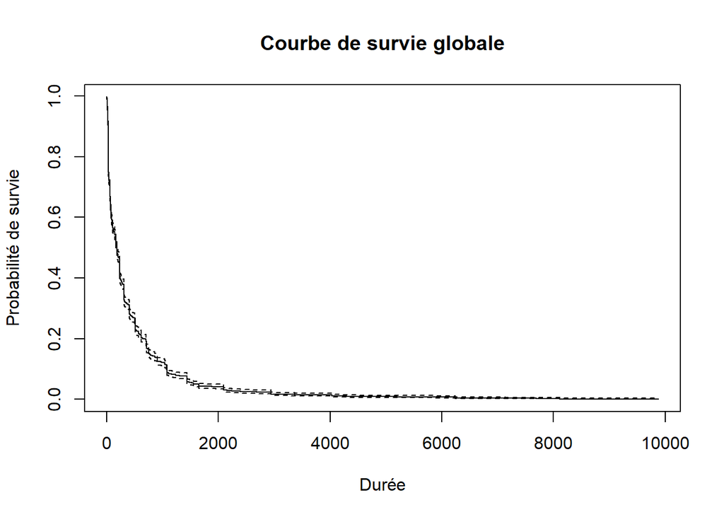

```r
surv_obj <- Surv(Duree, censure == 1)
km_global <- survfit(surv_obj ~ 1)
plot(km_global, main = "Courbe de survie globale", xlab = "Durée", ylab = "Probabilité de survie")
```

### Comparaisons selon variables catégorielles

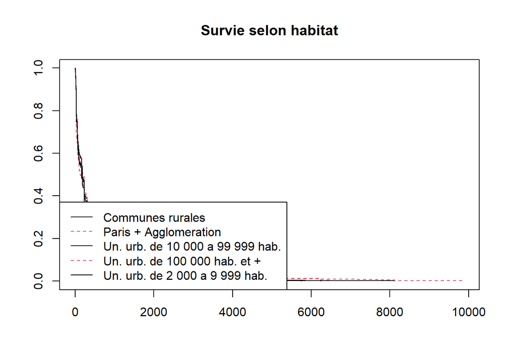

```r
km_habitat <- survfit(surv_obj ~ Ahabi)
plot(km_habitat, col = 1:2, lty = 1:2, main = "Survie selon habitat")
legend("bottomleft", legend = levels(Ahabi), col = 1:2, lty = 1:2)
```

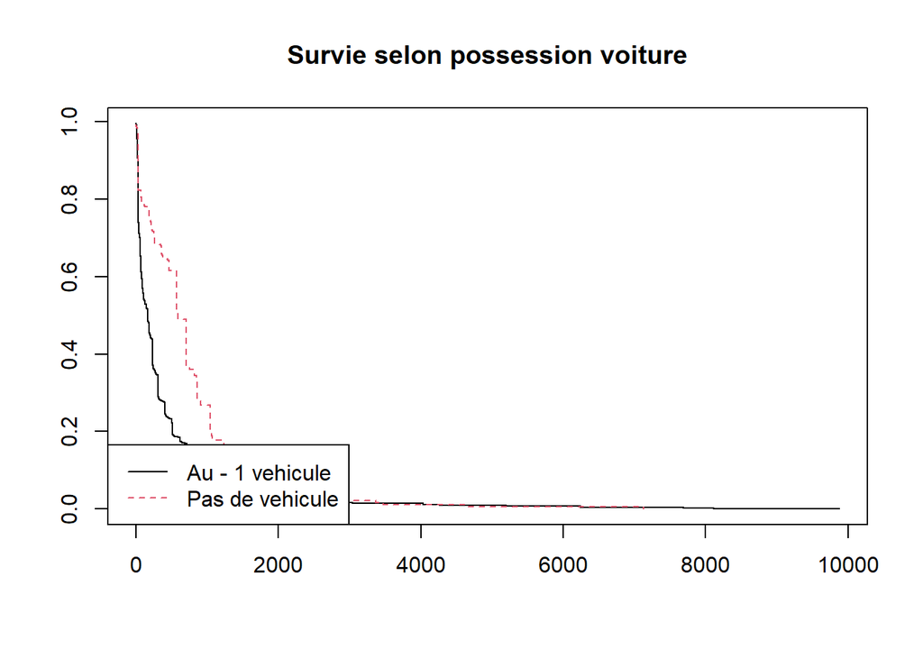

```r
km_vehicule <- survfit(surv_obj ~ Bauto)
plot(km_vehicule, col = 1:2, lty = 1:2, main = "Survie selon possession voiture")
legend("bottomleft", legend = levels(Bauto), col = 1:2, lty = 1:2)
```

### Modèle de Cox

```r
cox_model <- coxph(surv_obj ~ Ahabi + Bauto + nbpers)
summary(cox_model)
```

```
## Call:
## coxph(formula = surv_obj ~ Ahabi + Bauto + nbpers)
##
##   n= 5352, number of events= 3307
##
##                                           coef exp(coef) se(coef)      z
## AhabiParis + Agglomeration            -0.04812   0.95302  0.05777 -0.833
## AhabiUn. urb. de 10 000 a 99 999 hab. -0.02566   0.97466  0.05550 -0.462
## AhabiUn. urb. de 100 000 hab. et +    -0.11927   0.88757  0.05019 -2.376
## AhabiUn. urb. de 2 000 a 9 999 hab.    0.04967   1.05093  0.06631  0.749
## BautoPas de vehicule                  -0.24519   0.78255  0.06812 -3.599
## nbpers                                 0.59009   1.80415  0.01191 49.527
##                                       Pr(>|z|)
## AhabiParis + Agglomeration            0.404875
## AhabiUn. urb. de 10 000 a 99 999 hab. 0.643821
## AhabiUn. urb. de 100 000 hab. et +    0.017489 *
## AhabiUn. urb. de 2 000 a 9 999 hab.   0.453818
## BautoPas de vehicule                  0.000319 ***
## nbpers                                 < 2e-16 ***
## ---
## Signif. codes:  0 '***' 0.001 '**' 0.01 '*' 0.05 '.' 0.1 ' ' 1
##
##                                       exp(coef) exp(-coef) lower .95 upper .95
## AhabiParis + Agglomeration               0.9530     1.0493    0.8510    1.0673
## AhabiUn. urb. de 10 000 a 99 999 hab.    0.9747     1.0260    0.8742    1.0867
## AhabiUn. urb. de 100 000 hab. et +       0.8876     1.1267    0.8044    0.9793
## AhabiUn. urb. de 2 000 a 9 999 hab.      1.0509     0.9515    0.9228    1.1968
## BautoPas de vehicule                     0.7826     1.2779    0.6847    0.8943
## nbpers                                   1.8041     0.5543    1.7625    1.8468
##
## Concordance= 0.765  (se = 0.006 )
## Likelihood ratio test= 1665  on 6 df,   p=<2e-16
## Wald test            = 2573  on 6 df,   p=<2e-16
## Score (logrank) test = 2308  on 6 df,   p=<2e-16
```

# Annexe

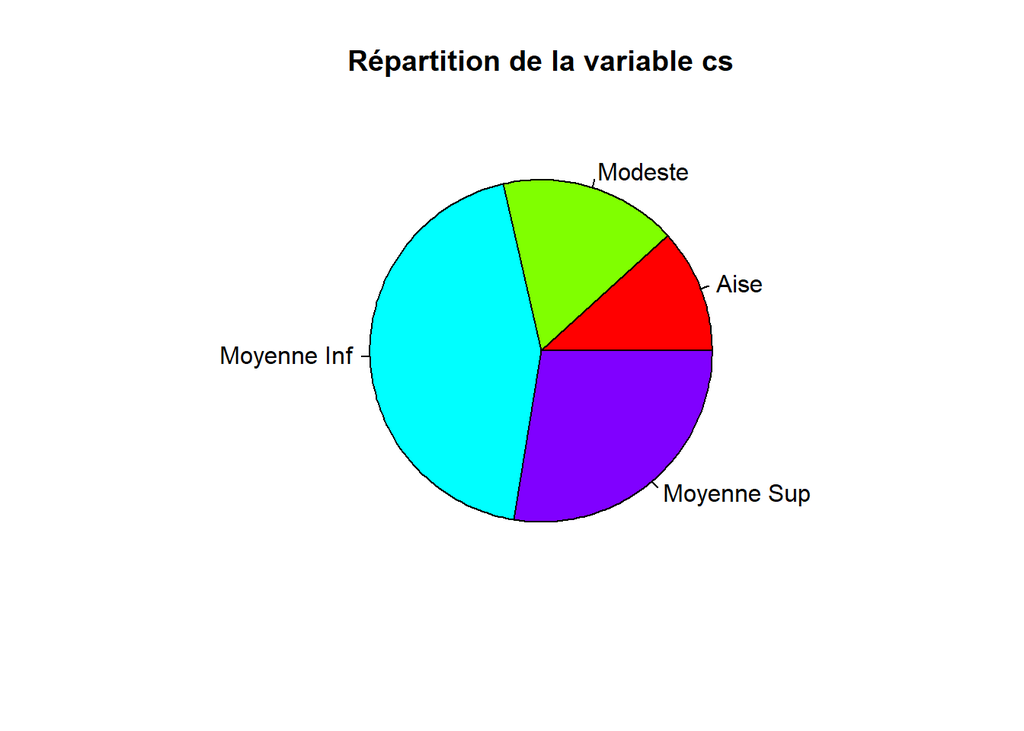

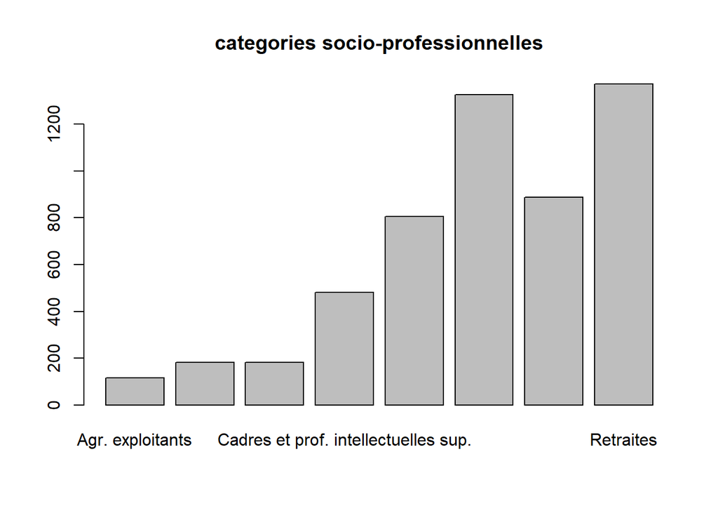

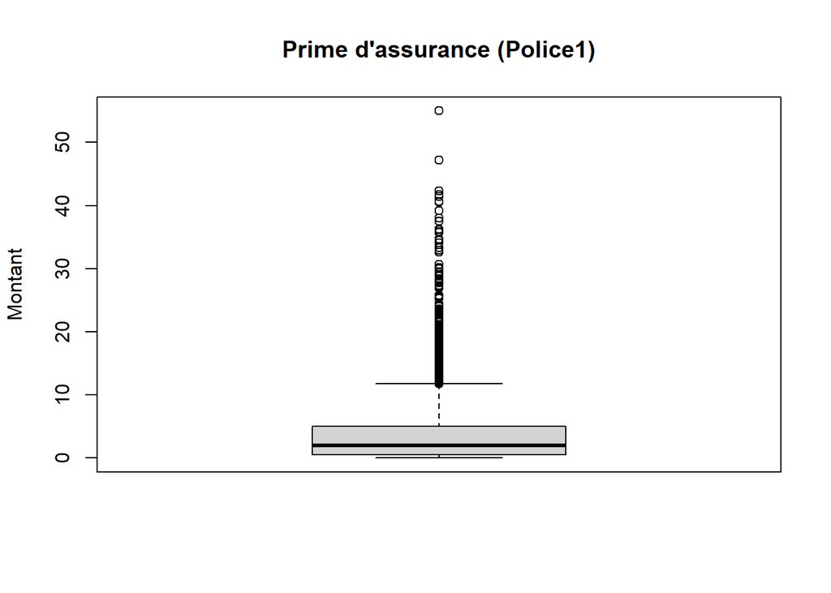

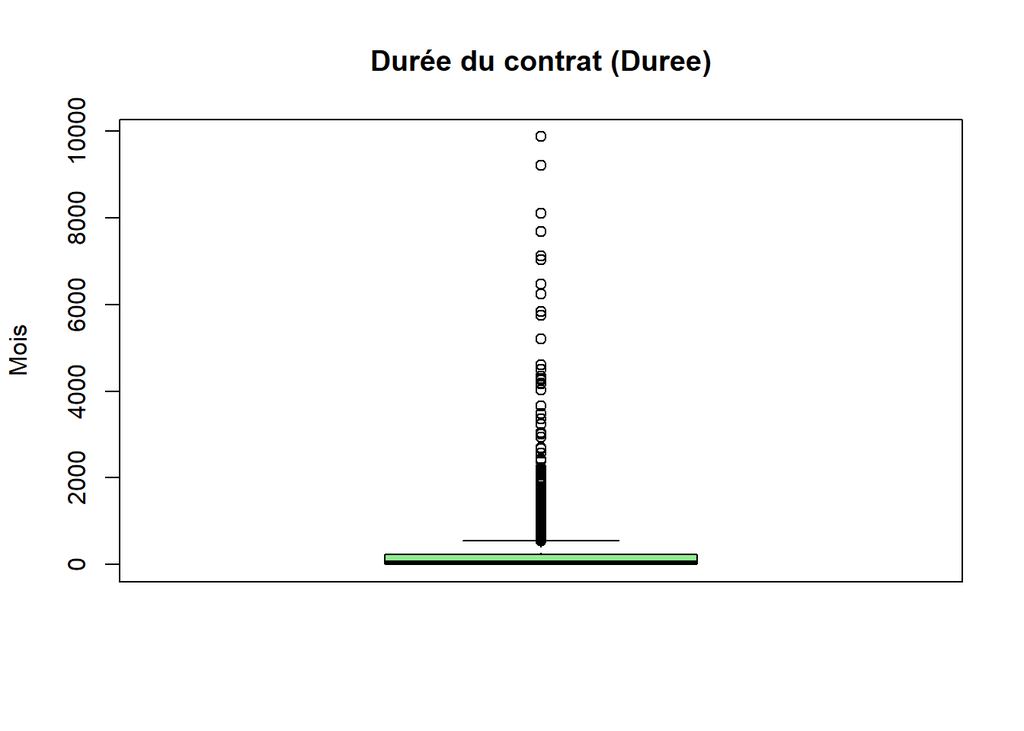

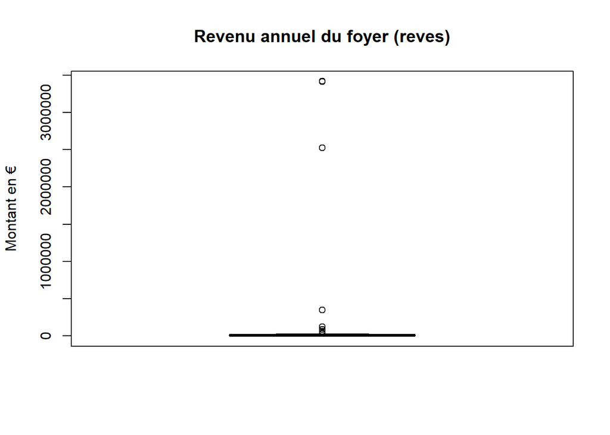

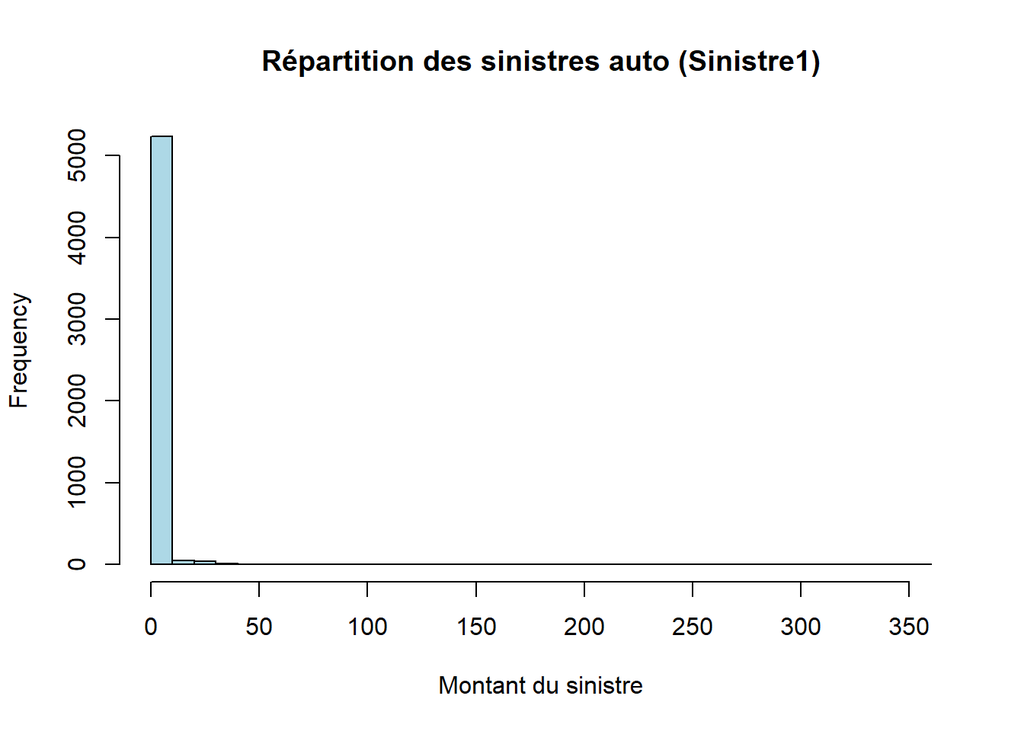

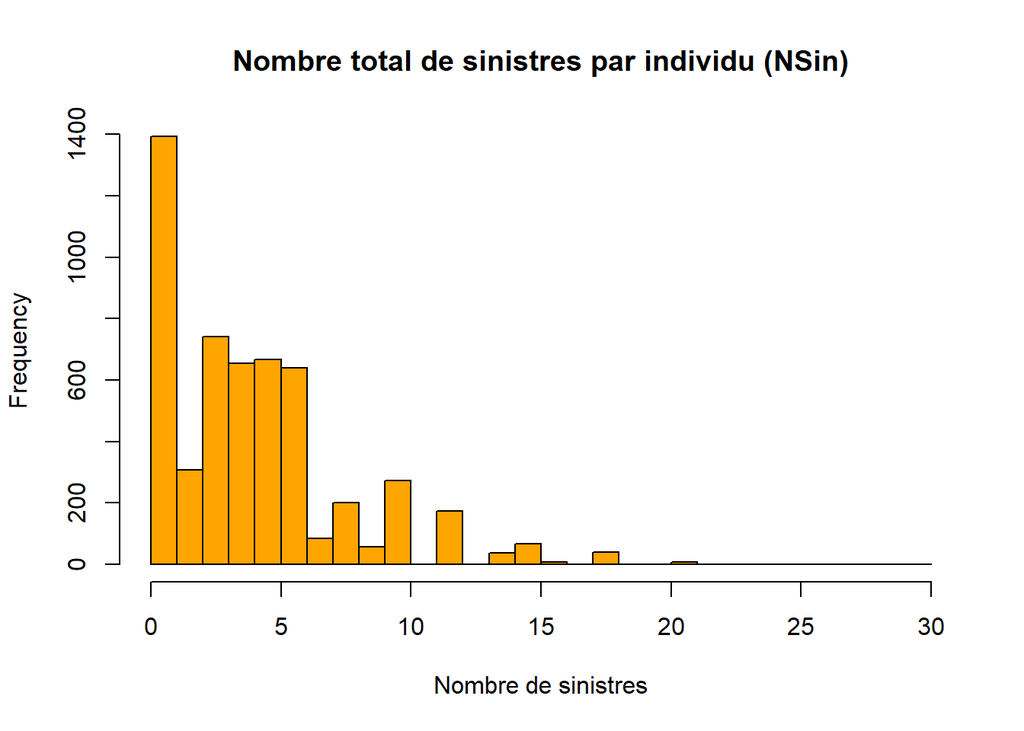

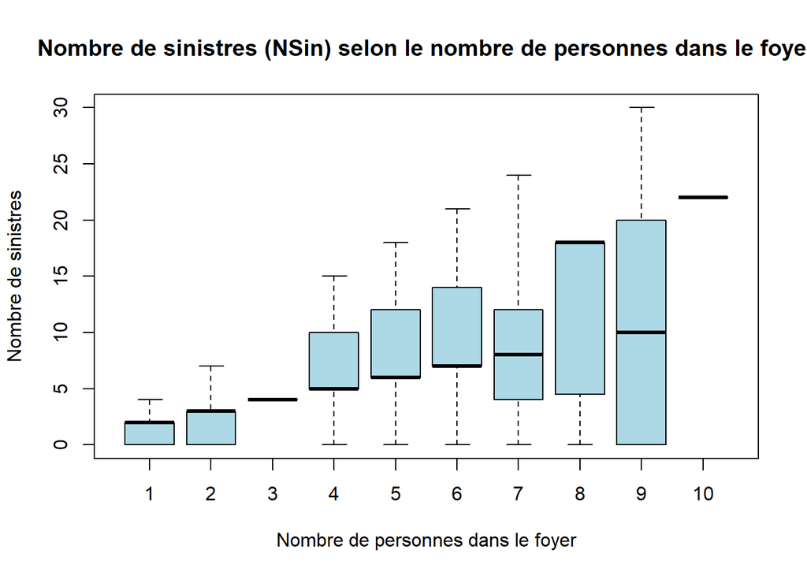

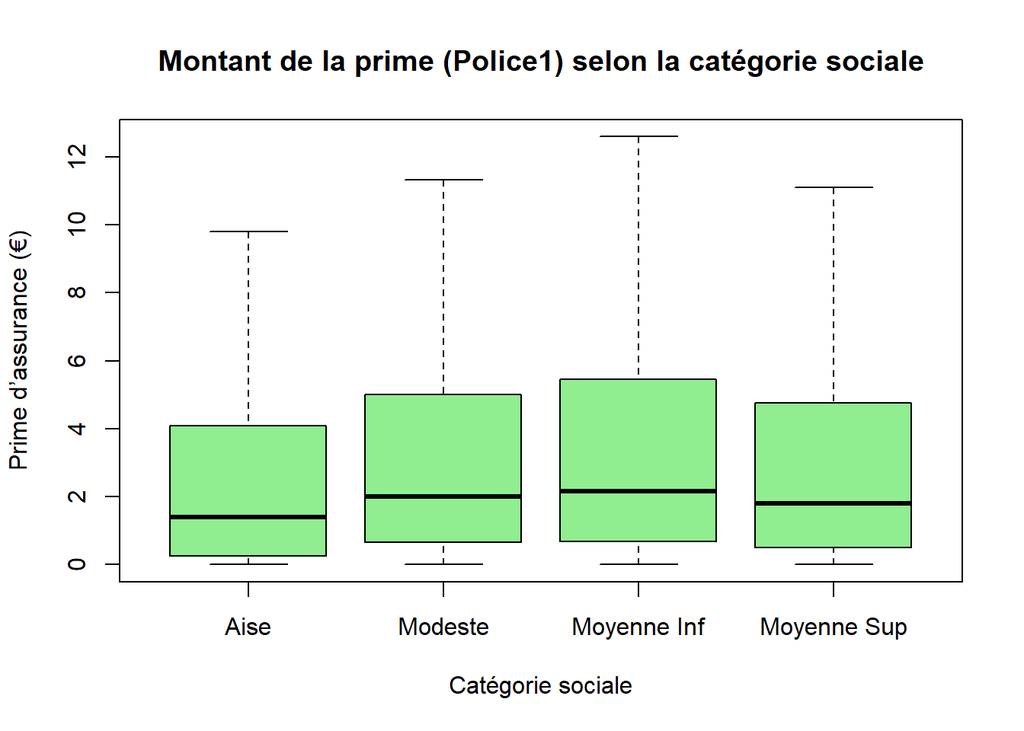

```
##
## Call:
## glm(formula = Sinistre0 ~ crevpp + enfants + region + habi, family = gaussian(link = "identity"),
##     data = dat2)
##
## Coefficients:
##                      Estimate Std. Error t value Pr(>|t|)
## (Intercept)           9.88360    0.22002  44.922  < 2e-16 ***
## crevpp2eme quartile   0.32852    0.08889   3.696 0.000221 ***
## crevpp3eme quartile   0.65061    0.08723   7.459 1.02e-13 ***
## crevpp4eme quartile   1.56257    0.09106  17.160  < 2e-16 ***
## enfantsPas d'enfants  7.89866    0.07265 108.716  < 2e-16 ***
## region2              -0.41870    0.21457  -1.951 0.051065 .
## region3              -0.40585    0.23287  -1.743 0.081417 .
## region4              -0.31878    0.22314  -1.429 0.153180
## region5              -0.28663    0.21676  -1.322 0.186111
## region7              -0.05732    0.22390  -0.256 0.797947
## region8              -0.31516    0.21993  -1.433 0.151911
## region9              -0.22799    0.22521  -1.012 0.311407
## habi1                 0.02028    0.12850   0.158 0.874615
## habi2                 0.11638    0.14548   0.800 0.423752
## habi3                -0.12004    0.14567  -0.824 0.409968
## habi4                -0.12529    0.12983  -0.965 0.334552
## habi5                -0.11978    0.12812  -0.935 0.349884
## habi6                 0.02358    0.12064   0.195 0.845055
## habi7                 0.08789    0.09182   0.957 0.338495
## habi8                -0.03907    0.22378  -0.175 0.861420
## ---
## Signif. codes:  0 '***' 0.001 '**' 0.01 '*' 0.05 '.' 0.1 ' ' 1
##
## (Dispersion parameter for gaussian family taken to be 4.808615)
##
##     Null deviance: 98740  on 5351  degrees of freedom
## Residual deviance: 25640  on 5332  degrees of freedom
## AIC: 23615
##
## Number of Fisher Scoring iterations: 2
```

```
##
##  studentized Breusch-Pagan test
##
## data:  glm_priori
## BP = 54.785, df = 19, p-value = 2.507e-05
```

```
##
## z test of coefficients:
##
##                       Estimate Std. Error  z value  Pr(>|z|)
## (Intercept)           9.883601   0.219143  45.1011 < 2.2e-16 ***
## crevpp2eme quartile   0.328523   0.085039   3.8632 0.0001119 ***
## crevpp3eme quartile   0.650614   0.083977   7.7475 9.373e-15 ***
## crevpp4eme quartile   1.562568   0.092652  16.8649 < 2.2e-16 ***
## enfantsPas d'enfants  7.898664   0.069574 113.5290 < 2.2e-16 ***
## region2              -0.418701   0.214011  -1.9564 0.0504132 .
## region3              -0.405854   0.231403  -1.7539 0.0794503 .
## region4              -0.318776   0.222413  -1.4333 0.1517824
## region5              -0.286632   0.216441  -1.3243 0.1854058
## region7              -0.057321   0.222748  -0.2573 0.7969193
## region8              -0.315157   0.219540  -1.4355 0.1511343
## region9              -0.227991   0.224264  -1.0166 0.3093333
## habi1                 0.020279   0.127312   0.1593 0.8734464
## habi2                 0.116383   0.144659   0.8045 0.4210884
## habi3                -0.120035   0.141043  -0.8511 0.3947378
## habi4                -0.125295   0.123703  -1.0129 0.3111225
## habi5                -0.119782   0.123606  -0.9691 0.3325145
## habi6                 0.023577   0.117333   0.2009 0.8407412
## habi7                 0.087889   0.091591   0.9596 0.3372704
## habi8                -0.039067   0.225569  -0.1732 0.8624997
## ---
## Signif. codes:  0 '***' 0.001 '**' 0.01 '*' 0.05 '.' 0.1 ' ' 1
```

```
##
## Call:
## ivreg(formula = Sinistre0 ~ crevpp + enfants + Police1 + Police2 +
##     Police3 | crevpp + enfants + region + habi + cs + Police2 +
##     Police3, data = dat2)
##
## Residuals:
##       Min        1Q    Median        3Q       Max
## -8.995733 -1.501499  0.002514  1.517931  8.460324
##
## Coefficients:
##                        Estimate Std. Error t value Pr(>|t|)
## (Intercept)           9.2560455  0.1310904  70.608  < 2e-16 ***
## crevpp2eme quartile   0.3361686  0.0881092   3.815 0.000138 ***
## crevpp3eme quartile   0.7179469  0.0856764   8.380  < 2e-16 ***
## crevpp4eme quartile   1.7175985  0.0952171  18.039  < 2e-16 ***
## enfantsPas d'enfants  7.8722559  0.0753292 104.505  < 2e-16 ***
## Police1               0.0847950  0.0347945   2.437 0.014841 *
## Police2              -0.0008754  0.0031476  -0.278 0.780931
## Police3               0.0112057  0.0123798   0.905 0.365419
##
## Diagnostic tests:
##                   df1  df2 statistic p-value
## Weak instruments   18 5327     14.91  <2e-16 ***
## Wu-Hausman          1 5343      4.51  0.0337 *
## Sargan             17   NA    118.20  <2e-16 ***
## ---
## Signif. codes:  0 '***' 0.001 '**' 0.01 '*' 0.05 '.' 0.1 ' ' 1
##
## Residual standard error: 2.224 on 5344 degrees of freedom
## Multiple R-Squared: 0.7324,  Adjusted R-squared: 0.7321
## Wald test:  2263 on 7 and 5344 DF,  p-value: < 2.2e-16
```

```
##
## Call:
## lm(formula = Police1 ~ crevpp + enfants + region + habi + cs,
##     data = dat2)
##
## Residuals:
##    Min     1Q Median     3Q    Max
## -5.562 -3.000 -1.509  1.237 50.934
##
## Coefficients:
##                      Estimate Std. Error t value Pr(>|t|)
## (Intercept)           5.80188    0.61897   9.373  < 2e-16 ***
## crevpp2eme quartile  -0.23071    0.26752  -0.862 0.388496
## crevpp3eme quartile  -1.06744    0.29956  -3.563 0.000369 ***
## crevpp4eme quartile  -1.99602    0.37282  -5.354 8.97e-08 ***
## enfantsPas d'enfants  0.27777    0.16499   1.684 0.092325 .
## region2              -0.06378    0.48402  -0.132 0.895179
## region3              -2.38398    0.52515  -4.540 5.76e-06 ***
## region4              -1.41732    0.50309  -2.817 0.004862 **
## region5              -0.60559    0.48892  -1.239 0.215537
## region7               0.05109    0.50489   0.101 0.919397
## region8               0.28964    0.49579   0.584 0.559112
## region9               0.57587    0.50784   1.134 0.256857
## habi1                -0.62012    0.28962  -2.141 0.032305 *
## habi2                -0.27900    0.32794  -0.851 0.394933
## habi3                -0.44897    0.32833  -1.367 0.171554
## habi4                -0.46207    0.29262  -1.579 0.114380
## habi5                -0.20856    0.28908  -0.721 0.470659
## habi6                -0.17733    0.27193  -0.652 0.514351
## habi7                -0.45886    0.20694  -2.217 0.026641 *
## habi8                -1.13285    0.50466  -2.245 0.024822 *
## csModeste            -1.34335    0.44119  -3.045 0.002339 **
## csMoyenne Inf        -0.80742    0.34055  -2.371 0.017780 *
## csMoyenne Sup        -0.25249    0.26108  -0.967 0.333527
## ---
## Signif. codes:  0 '***' 0.001 '**' 0.01 '*' 0.05 '.' 0.1 ' ' 1
##
## Residual standard error: 4.942 on 5329 degrees of freedom
## Multiple R-squared:  0.03498,    Adjusted R-squared:  0.031
## F-statistic:  8.78 on 22 and 5329 DF,  p-value: < 2.2e-16
```

```
##
## Call:
## glm(formula = Sinistre0 ~ crevpp + enfants + Police1 + resid_first,
##     family = gaussian(link = "identity"), data = dat2)
##
## Coefficients:
##                      Estimate Std. Error t value Pr(>|t|)
## (Intercept)           9.25537    0.15876  58.297  < 2e-16 ***
## crevpp2eme quartile   0.33572    0.08871   3.785 0.000156 ***
## crevpp3eme quartile   0.72109    0.08696   8.292  < 2e-16 ***
## crevpp4eme quartile   1.72155    0.09409  18.297  < 2e-16 ***
## enfantsPas d'enfants  7.87192    0.07294 107.927  < 2e-16 ***
## Police1               0.08782    0.03568   2.461 0.013885 *
## resid_first          -0.07670    0.03620  -2.119 0.034152 *
## ---
## Signif. codes:  0 '***' 0.001 '**' 0.01 '*' 0.05 '.' 0.1 ' ' 1
##
## (Dispersion parameter for gaussian family taken to be 4.811743)
##
##     Null deviance: 98740  on 5351  degrees of freedom
## Residual deviance: 25719  on 5345  degrees of freedom
## AIC: 23606
##
## Number of Fisher Scoring iterations: 2
```

```
##
## Call:
## tobit(formula = Sinistre1 ~ pcs + lruc + Ahabi + agecat + nbpers +
##     enfants + Anat + Bauto, left = 0, data = dat)
##
## Observations:
##          Total  Left-censored     Uncensored Right-censored
##           5352           4085           1267              0
##
## Coefficients:
##                                          Estimate Std. Error z value Pr(>|z|)
## (Intercept)                             -22.77965    9.31734  -2.445   0.0145
## pcsArtisans, comm., chefs d'ent.          2.07202    3.70470   0.559   0.5760
## pcsAutres pers. sans activite prof.       8.82257    3.64431   2.421   0.0155
## pcsCadres et prof. intellectuelles sup.   6.61519    3.36045   1.969   0.0490
## pcsEmployes                               6.18192    3.16254   1.955   0.0506
## pcsOuvriers                               4.79920    3.07502   1.561   0.1186
## pcsProfessions intermediaires             7.47787    3.16876   2.360   0.0183
## pcsRetraites                              4.12181    3.53184   1.167   0.2432
## lruc                                     -0.74417    0.96454  -0.772   0.4404
## AhabiParis + Agglomeration                2.79426    1.44873   1.929   0.0538
## AhabiUn. urb. de 10 000 a 99 999 hab.     2.21255    1.22065   1.813   0.0699
## AhabiUn. urb. de 100 000 hab. et +        4.72658    1.09157   4.330 1.49e-05
## AhabiUn. urb. de 2 000 a 9 999 hab.      -0.20251    1.42776  -0.142   0.8872
## agecat41-50                              -2.23751    1.12051  -1.997   0.0458
## agecat51-60                              -2.96397    1.37727  -2.152   0.0314
## agecat61-96                              -5.26571    2.21600  -2.376   0.0175
## nbpers                                    1.64546    0.39168   4.201 2.66e-05
## enfantsPas d'enfants                      1.95404    1.14317   1.709   0.0874
## AnatMenage francais                      -0.79797    2.56190  -0.311   0.7554
## AnatNon declare                           0.70314    2.94387   0.239   0.8112
## BautoPas de vehicule                     -1.75235    1.58949  -1.102   0.2703
## Log(scale)                                3.03878    0.02109 144.109  < 2e-16
##
## (Intercept)                             *
## pcsArtisans, comm., chefs d'ent.
## pcsAutres pers. sans activite prof.     *
## pcsCadres et prof. intellectuelles sup. *
## pcsEmployes                             .
## pcsOuvriers
```

[output cut: 10 more lines]

```
## nbpers                                  ***
## enfantsPas d'enfants                    .
## AnatMenage francais
## AnatNon declare
## BautoPas de vehicule
## Log(scale)                              ***
## ---
## Signif. codes:  0 '***' 0.001 '**' 0.01 '*' 0.05 '.' 0.1 ' ' 1
##
## Scale: 20.88
##
## Gaussian distribution
## Number of Newton-Raphson Iterations: 4
## Log-likelihood: -7088 on 22 Df
## Wald-statistic: 127.1 on 20 Df, p-value: < 2.22e-16
```

```
##
## Call:
## mhurdle(formula = Sinistre1 ~ lruc | pcs + lruc + region + Ahabi +
##     agecat + nbpers + enfants + Anat + Bauto | 0, data = dat,
##     dist = "n", h2 = TRUE, corr = FALSE, robust = TRUE)
##
## Frequency of 0:  0.76327
##
## Newton-Raphson maximisation method
## 0 iterations, 0h:0m:2s
## g'(-H)^-1g =    NA
##
##
## Coefficients :
##                                              Estimate Std. Error t-value
## h1.(Intercept)                               5.453235 530.212579  0.0103
## h1.lruc                                     -0.030204  61.608020 -0.0005
## h2.(Intercept)                             -20.406396   7.712138 -2.6460
## h2.pcsArtisans, comm., chefs d'ent.          1.704629   2.871636  0.5936
## h2.pcsAutres pers. sans activite prof.       6.846750   2.825035  2.4236
## h2.pcsCadres et prof. intellectuelles sup.   5.055531   2.604680  1.9409
## h2.pcsEmployes                               4.747937   2.452390  1.9360
## h2.pcsOuvriers                               3.776749   2.385332  1.5833
## h2.pcsProfessions intermediaires             5.826273   2.457938  2.3704
## h2.pcsRetraites                              3.180742   2.738057  1.1617
## h2.lruc                                     -0.505862   0.753512 -0.6713
## h2.region2                                   2.155786   2.280001  0.9455
## h2.region3                                   3.517690   2.438675  1.4425
## h2.region4                                   1.706822   2.366154  0.7213
## h2.region5                                   1.752503   2.313085  0.7576
## h2.region7                                   2.028293   2.381813  0.8516
## h2.region8                                   2.697434   2.314759  1.1653
## h2.region9                                   4.515939   2.357061  1.9159
## h2.AhabiParis + Agglomeration                4.363052   2.377486  1.8352
## h2.AhabiUn. urb. de 10 000 a 99 999 hab.     1.516962   0.951743  1.5939
## h2.AhabiUn. urb. de 100 000 hab. et +        3.151321   0.872723  3.6109
## h2.AhabiUn. urb. de 2 000 a 9 999 hab.      -0.335950   1.110592 -0.3025
## h2.agecat41-50                              -1.876156   0.870947 -2.1542
## h2.agecat51-60                              -2.368832   1.067874 -2.2183
## h2.agecat61-96                              -4.231968   1.719844 -2.4607
```

[output cut: 31 more lines]

```
## h2.agecat61-96                             0.0138678 *
## h2.nbpers                                  2.238e-05 ***
## h2.enfantsPas d'enfants                    0.0796075 .
## h2.AnatMenage francais                     0.7302783
## h2.AnatNon declare                         0.8003876
## h2.BautoPas de vehicule                    0.2914178
## sd.sd                                      < 2.2e-16 ***
## ---
## Signif. codes:  0 '***' 0.001 '**' 0.01 '*' 0.05 '.' 0.1 ' ' 1
##
## Log-Likelihood: -6759.9 on 31 Df
##
## R^2 :
##  Coefficient of determination : -5462.5
##  Likelihood ratio index       : 0.010569
```

```
##
## Call:
## mhurdle(formula = Sinistre1 ~ lruc | pcs + lruc + region + Ahabi +
##     agecat + nbpers + enfants + Anat + Bauto | 0, data = dat,
##     dist = "n", h2 = FALSE, corr = TRUE, robust = TRUE)
##
## Frequency of 0:  0.76327
##
## Newton-Raphson maximisation method
## 0 iterations, 0h:0m:2s
## g'(-H)^-1g =    NA
##
##
## Coefficients :
##                                              Estimate Std. Error t-value
## h1.(Intercept)                               0.162041   0.297663  0.5444
## h1.lruc                                     -0.102355   0.034591 -2.9590
## h2.(Intercept)                             -17.315484  15.400496 -1.1243
## h2.pcsArtisans, comm., chefs d'ent.         -1.417322   5.937188 -0.2387
## h2.pcsAutres pers. sans activite prof.       2.248866   5.800434  0.3877
## h2.pcsCadres et prof. intellectuelles sup.   2.177819   5.352069  0.4069
## h2.pcsEmployes                               1.349825   5.139130  0.2627
## h2.pcsOuvriers                               2.628595   4.970699  0.5288
## h2.pcsProfessions intermediaires             2.011195   5.151880  0.3904
## h2.pcsRetraites                              1.276925   5.569529  0.2293
## h2.lruc                                      1.234806   1.502863  0.8216
## h2.region2                                   3.354068   4.634062  0.7238
## h2.region3                                   5.217213   4.881779  1.0687
## h2.region4                                   3.913836   4.797256  0.8158
## h2.region5                                   4.460875   4.697279  0.9497
## h2.region7                                   3.983725   4.850262  0.8213
## h2.region8                                   2.670881   4.703425  0.5679
## h2.region9                                   2.309751   4.851537  0.4761
## h2.AhabiParis + Agglomeration                2.066956   4.932379  0.4191
## h2.AhabiUn. urb. de 10 000 a 99 999 hab.    -0.062152   1.906574 -0.0326
## h2.AhabiUn. urb. de 100 000 hab. et +        0.951819   1.808467  0.5263
## h2.AhabiUn. urb. de 2 000 a 9 999 hab.      -1.204476   2.192339 -0.5494
## h2.agecat41-50                              -0.703710   1.644856 -0.4278
## h2.agecat51-60                              -0.242221   2.045249 -0.1184
## h2.agecat61-96                              -0.718720   3.641976 -0.1973
```

[output cut: 33 more lines]

```
## h2.nbpers                                   0.054881 .
## h2.enfantsPas d'enfants                     0.283552
## h2.AnatMenage francais                      0.774548
## h2.AnatNon declare                          0.821339
## h2.BautoPas de vehicule                     0.649128
## sd.sd                                      < 2.2e-16 ***
## corr12                                      0.171347
## ---
## Signif. codes:  0 '***' 0.001 '**' 0.01 '*' 0.05 '.' 0.1 ' ' 1
##
## Log-Likelihood: -7540.8 on 32 Df
##
## R^2 :
##  Coefficient of determination : -4870.6
##  Likelihood ratio index       : -0.2577
```